# Red Wine Quality Analysis by Aaron Wilson

```
##
## Call:
## lm(formula = df$quality ~ df$sulphates)
##
## Residuals:
##     Min      1Q  Median      3Q     Max
## -3.2432 -0.5424  0.1102  0.4456  2.3977
##
## Coefficients:
##              Estimate Std. Error t value Pr(>|t|)
## (Intercept)   4.84775    0.07842   61.82   <2e-16 ***
## df$sulphates  1.19771    0.11539   10.38   <2e-16 ***
## ---
## Signif. codes:  0 '***' 0.001 '**' 0.01 '*' 0.05 '.' 0.1 ' ' 1
##
## Residual standard error: 0.7819 on 1597 degrees of freedom
## Multiple R-squared:  0.0632, Adjusted R-squared:  0.06261
## F-statistic: 107.7 on 1 and 1597 DF,  p-value: < 2.2e-16
```

> The average sulphates goes up with quality. Using R^2 sulphates is responsible for 6% of the variation in quality ratings.

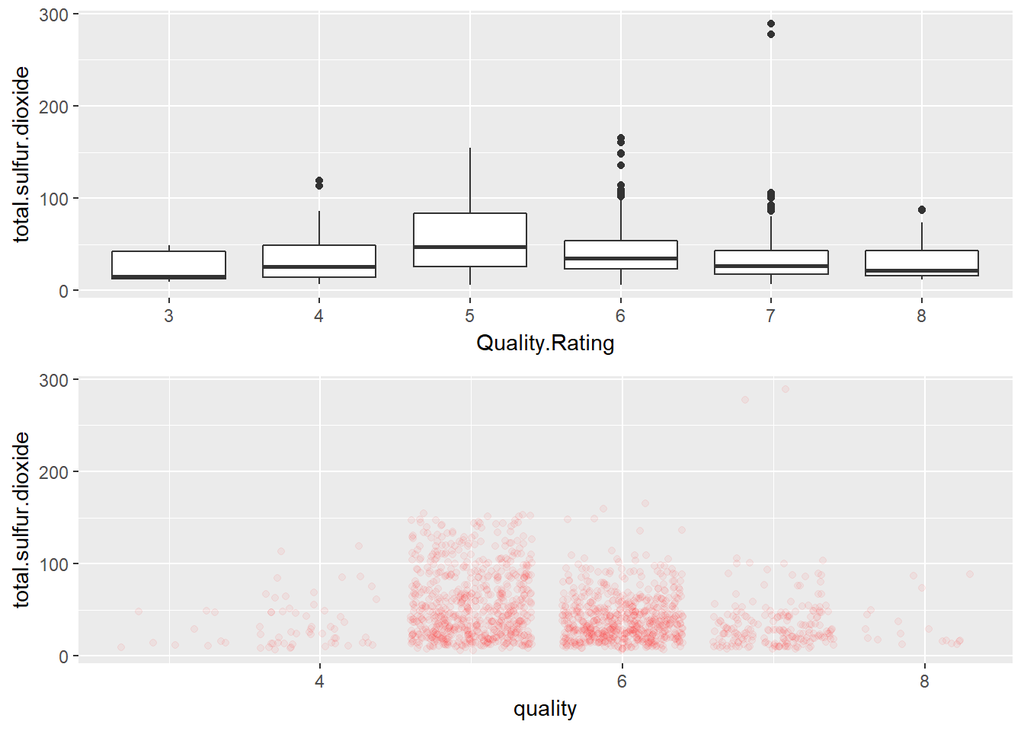

> Plotting quality and total sulfur dioxide there is not a trend between the quality levels. The variance is greatext at 5-7, but the mean is a normal distribution.

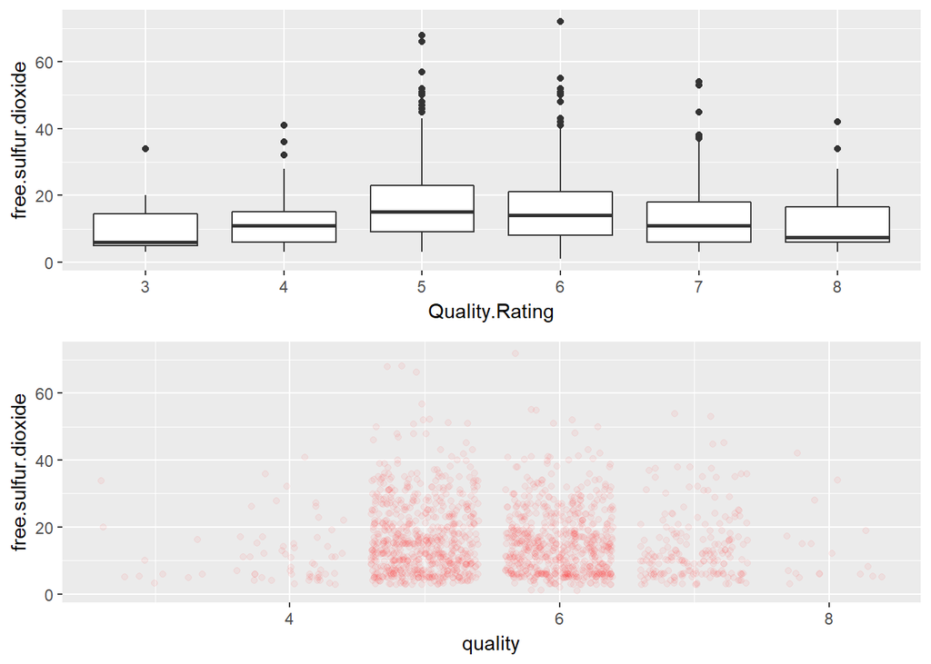

> Plotting quality and free sulfur dioxide there is not a trend between the quality levels. The variance is greatext at 5-6, but the mean is a normal distribution.

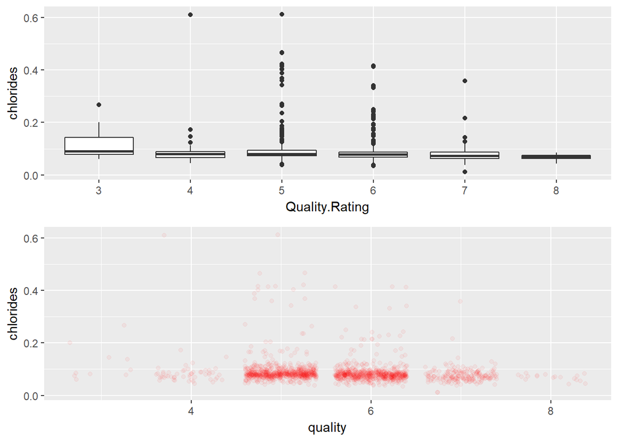

```
## df$quality: 3
##    Min. 1st Qu.  Median    Mean 3rd Qu.    Max.
##  0.0610  0.0790  0.0905  0.1225  0.1430  0.2670
## --------------------------------------------------------
## df$quality: 4
##    Min. 1st Qu.  Median    Mean 3rd Qu.    Max.
## 0.04500 0.06700 0.08000 0.09068 0.08900 0.61000
## --------------------------------------------------------
## df$quality: 5
##    Min. 1st Qu.  Median    Mean 3rd Qu.    Max.
## 0.03900 0.07400 0.08100 0.09274 0.09400 0.61100
## --------------------------------------------------------
## df$quality: 6
##    Min. 1st Qu.  Median    Mean 3rd Qu.    Max.
## 0.03400 0.06825 0.07800 0.08496 0.08800 0.41500
## --------------------------------------------------------
## df$quality: 7
##    Min. 1st Qu.  Median    Mean 3rd Qu.    Max.
## 0.01200 0.06200 0.07300 0.07659 0.08700 0.35800
## --------------------------------------------------------
## df$quality: 8
##    Min. 1st Qu.  Median    Mean 3rd Qu.    Max.
## 0.04400 0.06200 0.07050 0.06844 0.07550 0.08600
```

> Chlorides averages decrease as the quality levels of red wines increase.

```
##
## Call:
## lm(formula = df$quality ~ df$chlorides)
##
## Residuals:
##     Min      1Q  Median      3Q     Max
## -2.6946 -0.6503  0.3010  0.3607  2.3607
##
## Coefficients:
##              Estimate Std. Error t value Pr(>|t|)
## (Intercept)   5.82948    0.04229 137.852  < 2e-16 ***
## df$chlorides -2.21184    0.42578  -5.195 2.31e-07 ***
## ---
## Signif. codes:  0 '***' 0.001 '**' 0.01 '*' 0.05 '.' 0.1 ' ' 1
##
## Residual standard error: 0.8011 on 1597 degrees of freedom
## Multiple R-squared:  0.01662,    Adjusted R-squared:  0.016
## F-statistic: 26.99 on 1 and 1597 DF,  p-value: 2.313e-07
```

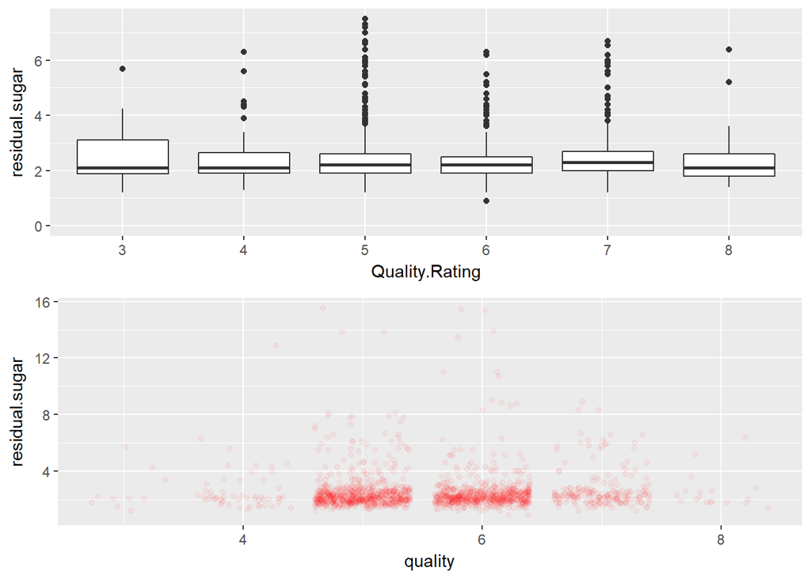

```
## df$quality: 3
##    Min. 1st Qu.  Median    Mean 3rd Qu.    Max.
##   1.200   1.875   2.100   2.635   3.100   5.700
## --------------------------------------------------------
## df$quality: 4
##    Min. 1st Qu.  Median    Mean 3rd Qu.    Max.
##   1.300   1.900   2.100   2.694   2.800  12.900
## --------------------------------------------------------
## df$quality: 5
##    Min. 1st Qu.  Median    Mean 3rd Qu.    Max.
##   1.200   1.900   2.200   2.529   2.600  15.500
## --------------------------------------------------------
## df$quality: 6
##    Min. 1st Qu.  Median    Mean 3rd Qu.    Max.
##   0.900   1.900   2.200   2.477   2.500  15.400
## --------------------------------------------------------
## df$quality: 7
##    Min. 1st Qu.  Median    Mean 3rd Qu.    Max.
##   1.200   2.000   2.300   2.721   2.750   8.900
## --------------------------------------------------------
## df$quality: 8
##    Min. 1st Qu.  Median    Mean 3rd Qu.    Max.
##   1.400   1.800   2.100   2.578   2.600   6.400
```

> The residual sugar levels are relatively consistent over the quality ratings.

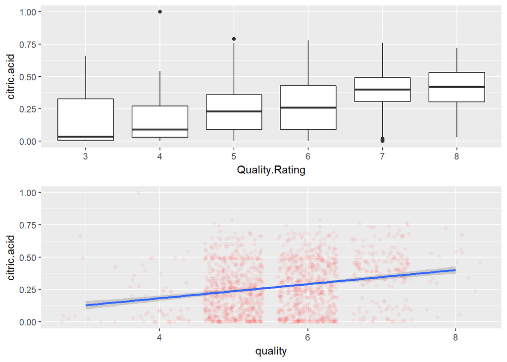

```
## df$quality: 3
##    Min. 1st Qu.  Median    Mean 3rd Qu.    Max.
##  0.0000  0.0050  0.0350  0.1710  0.3275  0.6600
## --------------------------------------------------------
## df$quality: 4
##    Min. 1st Qu.  Median    Mean 3rd Qu.    Max.
##  0.0000  0.0300  0.0900  0.1742  0.2700  1.0000
## --------------------------------------------------------
## df$quality: 5
##    Min. 1st Qu.  Median    Mean 3rd Qu.    Max.
##  0.0000  0.0900  0.2300  0.2437  0.3600  0.7900
## --------------------------------------------------------
## df$quality: 6
##    Min. 1st Qu.  Median    Mean 3rd Qu.    Max.
##  0.0000  0.0900  0.2600  0.2738  0.4300  0.7800
## --------------------------------------------------------
## df$quality: 7
##    Min. 1st Qu.  Median    Mean 3rd Qu.    Max.
##  0.0000  0.3050  0.4000  0.3752  0.4900  0.7600
## --------------------------------------------------------
## df$quality: 8
##    Min. 1st Qu.  Median    Mean 3rd Qu.    Max.
##  0.0300  0.3025  0.4200  0.3911  0.5300  0.7200
```

> There are higher average citric acid amounts with higher quality ratings. The ralationship is linear, with higher averages as it progresses.

```
##
## Call:
## lm(formula = df$quality ~ df$citric.acid)
##
## Residuals:
##     Min      1Q  Median      3Q     Max
## -3.0011 -0.5976  0.1021  0.5057  2.5901
##
## Coefficients:
##                Estimate Std. Error t value Pr(>|t|)
## (Intercept)     5.38172    0.03372 159.610   <2e-16 ***
## df$citric.acid  0.93845    0.10104   9.288   <2e-16 ***
## ---
## Signif. codes:  0 '***' 0.001 '**' 0.01 '*' 0.05 '.' 0.1 ' ' 1
##
## Residual standard error: 0.7869 on 1597 degrees of freedom
## Multiple R-squared:  0.05124,    Adjusted R-squared:  0.05065
## F-statistic: 86.26 on 1 and 1597 DF,  p-value: < 2.2e-16
```

> Using the R^2 measurement citric acid is 5 percent of the variation in quality ratings.

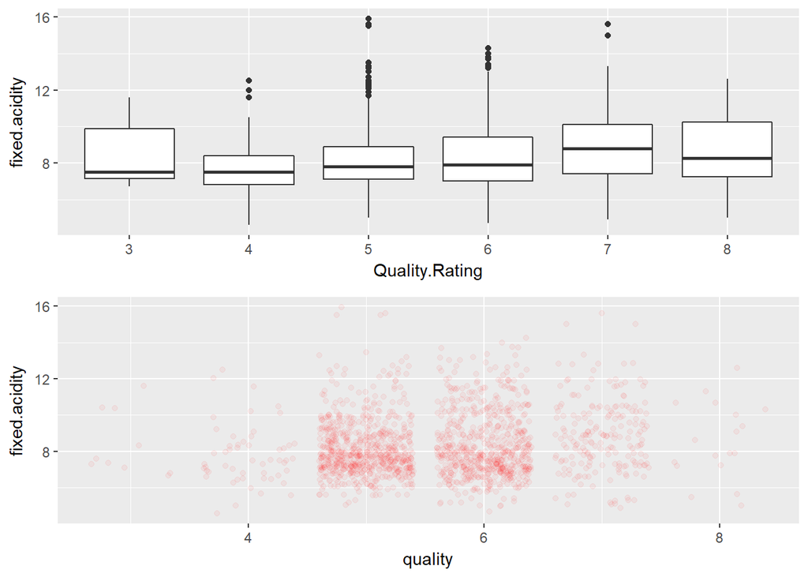

> The fixed acidity stays relatively consistent over the quality rating levels.

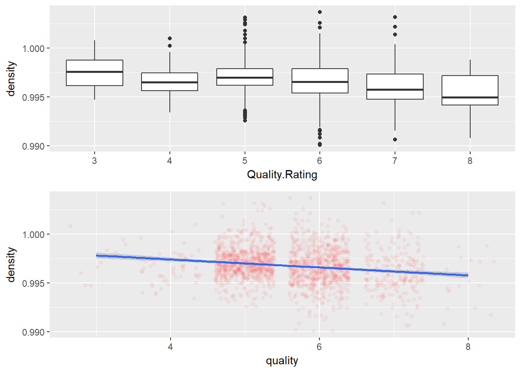

```
## df$quality: 3
##    Min. 1st Qu.  Median    Mean 3rd Qu.    Max.
##  0.9947  0.9961  0.9976  0.9975  0.9988  1.0008
## --------------------------------------------------------
## df$quality: 4
##    Min. 1st Qu.  Median    Mean 3rd Qu.    Max.
##  0.9934  0.9957  0.9965  0.9965  0.9974  1.0010
## --------------------------------------------------------
## df$quality: 5
##    Min. 1st Qu.  Median    Mean 3rd Qu.    Max.
##  0.9926  0.9962  0.9970  0.9971  0.9979  1.0031
## --------------------------------------------------------
## df$quality: 6
##    Min. 1st Qu.  Median    Mean 3rd Qu.    Max.
##  0.9901  0.9954  0.9966  0.9966  0.9979  1.0037
## --------------------------------------------------------
## df$quality: 7
##    Min. 1st Qu.  Median    Mean 3rd Qu.    Max.
##  0.9906  0.9948  0.9958  0.9961  0.9974  1.0032
## --------------------------------------------------------
## df$quality: 8
##    Min. 1st Qu.  Median    Mean 3rd Qu.    Max.
##  0.9908  0.9942  0.9949  0.9952  0.9972  0.9988
```

> For each quality rating the average density is dereasing in a linear pattern.

[output not shown]

> > Using the R^2 measurement density is 5 percent of the variation in quality ratings.

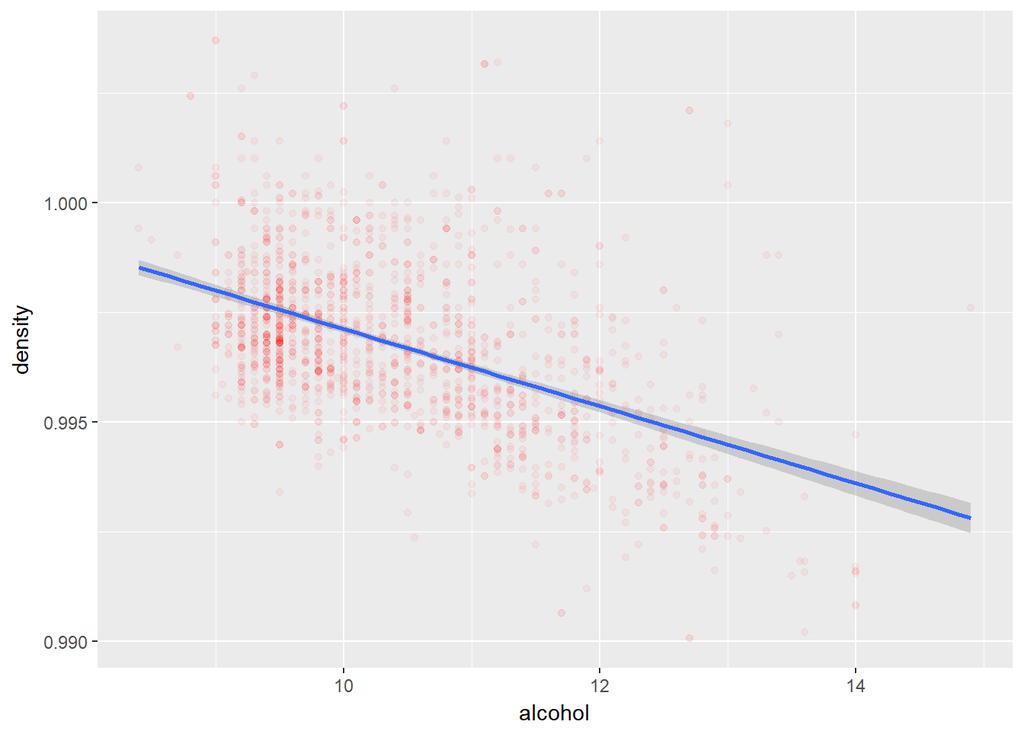

> The downhill weak correlation is linear between density and alcohol.

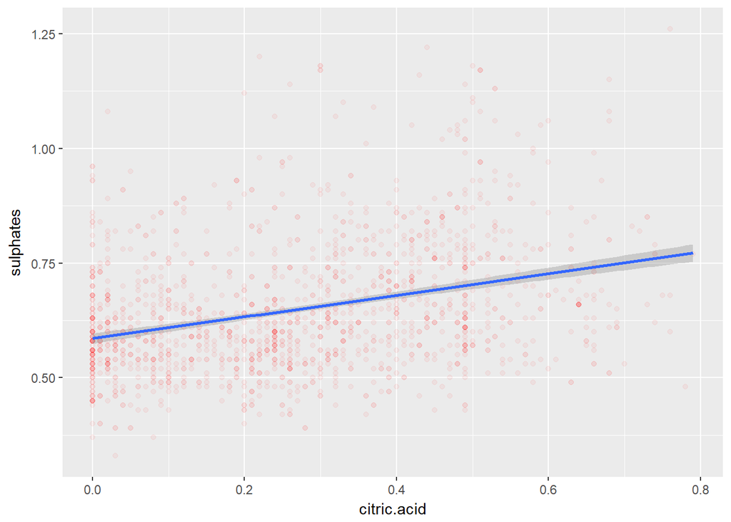

> The relationship between sulphates and citric acid does have a linear relationship.

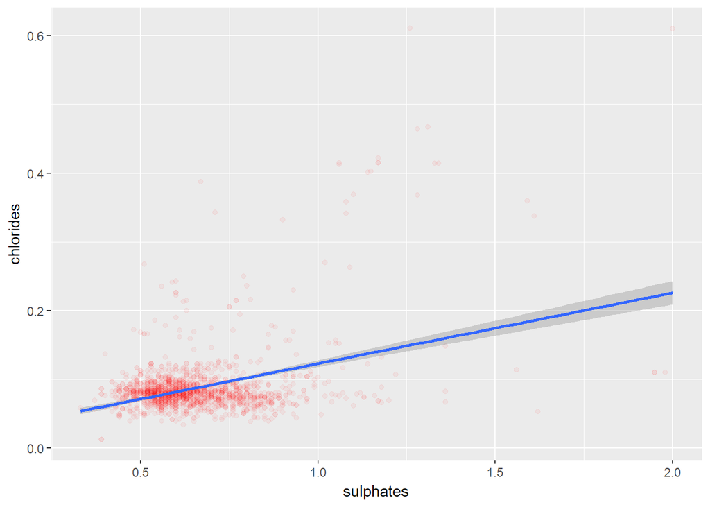

> The weak uphill correlation between sulphates and chlorides looks to be thrownoff by the roughly 30 datapoints way above the others. What will happen if I remove those outliers?

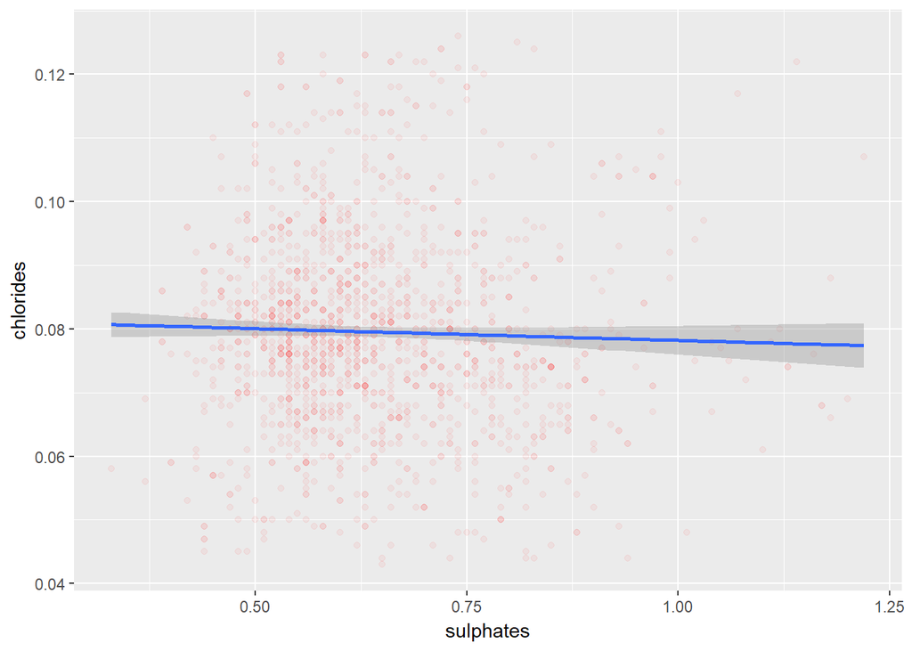

> Removing the really high and low chloride and sulphate wines and leaving just the mass of wines there is a slight downhill linear line, the the mass doesn’t have any visible correlation.

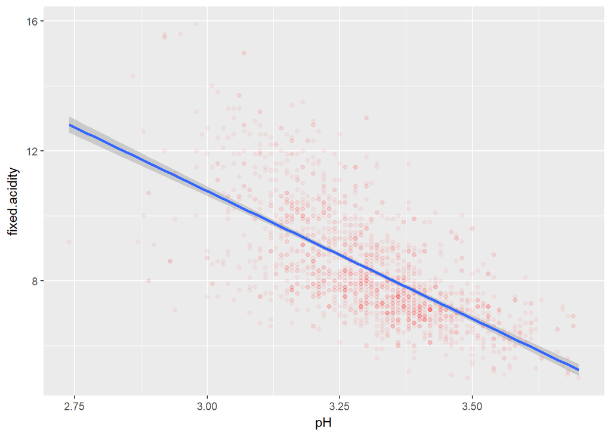

> pH and fixed acidity has a linear relationship, with more variation on the low pH end.

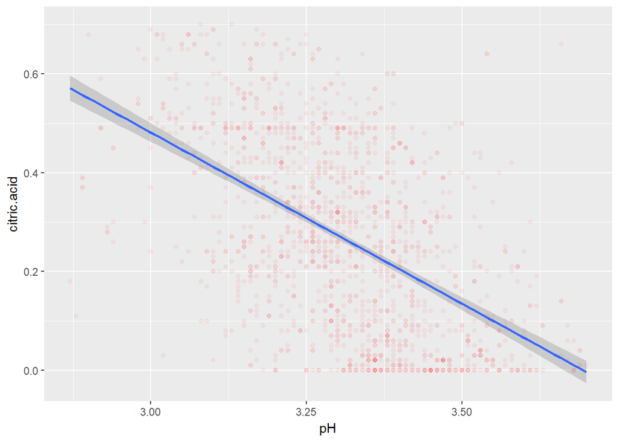

> pH and citric acid has a weak linear relationship. Near the high and low pH there is a lot of variation. There are also a lot of 0 citric acid wines between 3.25 and 3.75 pH, on the higher end of the PH scale. Because zero is the minimum this causes a massing.

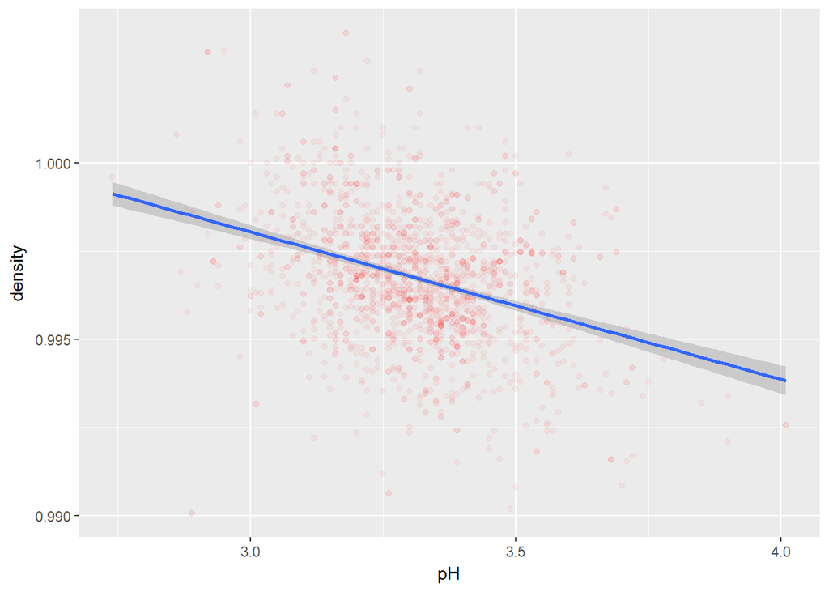

> There is a linear relationship between density and pH. A lot of the wines fall in a large massing in the center.

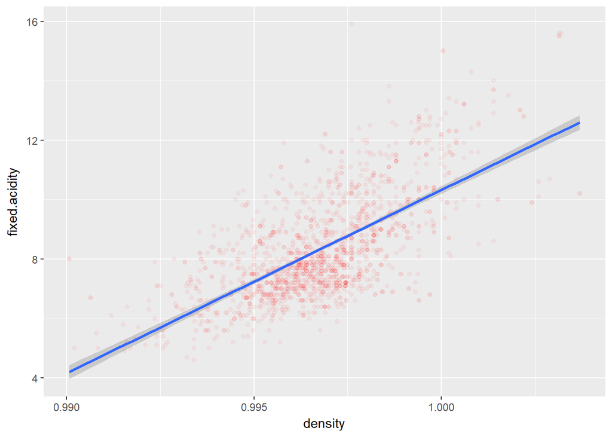

> There is a linear relationship between density and fixed acidity with a uphill correlation.

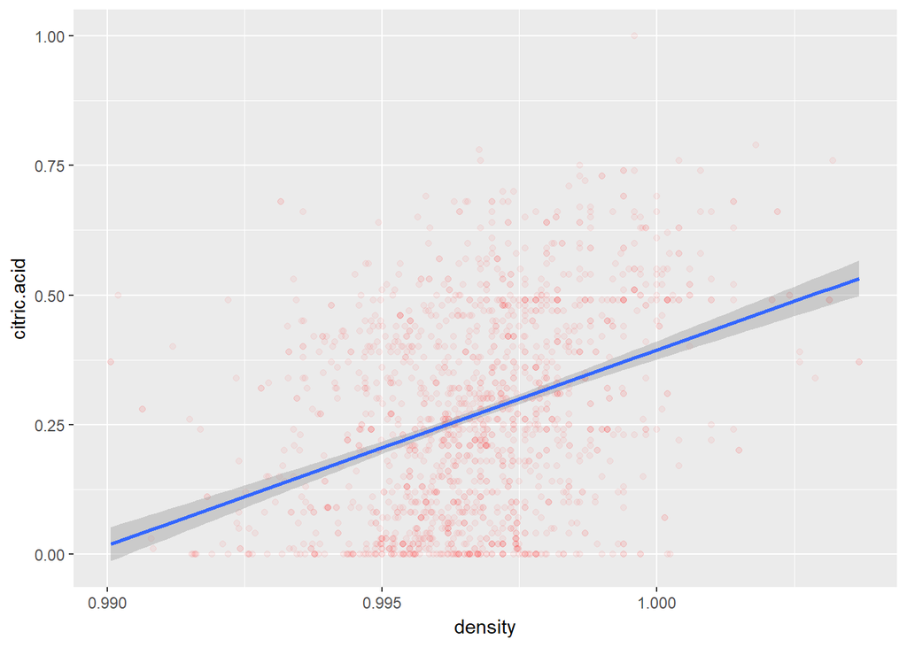

> The is a linear relationship between density and citric acid, though the floor of zero citric acid does come into play with a large number of the red wines in the dataset.

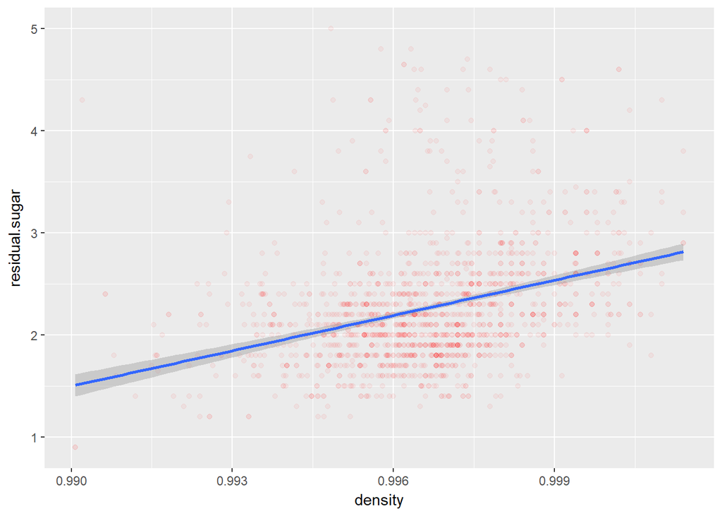

> Density and residual sugar has a linear relationship, with variation throughout.

# Bivariate Analysis

### Talk about some of the relationships you observed in this part of the investigation. How did the feature(s) of interest vary with other features in the dataset?

> The r^2 value indicates that 22 percent of the variance in ratings can be explained by the alcohol levels. The volatile acidity accounts for another 15 percent of the variance using the R^2. Sulphates are another 6 percent, and citric acid and density are each 5 percent of the variance. Other variables can be incorporated to explain the remaining variation.

> Higher alcohol, sulphates, and citric acid and lower volatile acidity are found in the wines with the higher quality ratings.

### Did you observe any interesting relationships between the other features (not the main feature(s) of interest)?

> Between density and alcohol and density and pH there is a downhill weak correlation. Density also has a positive linear relationship with residual sugar, citric acid, and fixed acidity.

> Between pH and both citric acid and fixed acidity there is a week downhill correlation.

> sulphates has an uphill correlation with Citric acid and chlorides, though when high cloride wines are removed directionality is lost.

### What was the strongest relationship you found?

> Alcohol and quality is the strongest relationship. though it is interesting the number of relationships to density, citric acid, pH, fixed acidity, and sulphates.

# Multivariate Plots Section

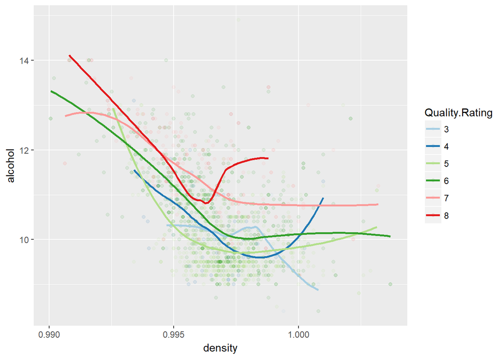

> At low density when plotted with alcohol levels the higher quality rated wines appear before the lower quality on the density scale.

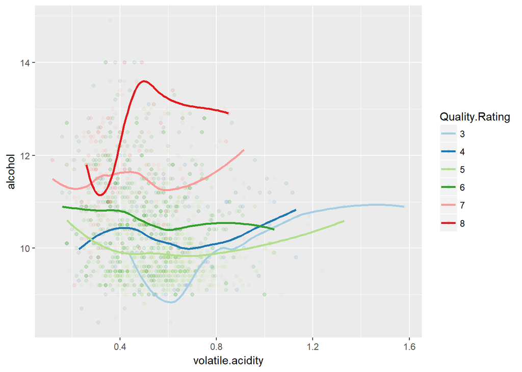

> At low volatile acidity when plotted with alcohol levels the higher quality rated wines appear before the lower quality and fizzle out by 0.9 while ratings 3-5 continue on past 1.1.

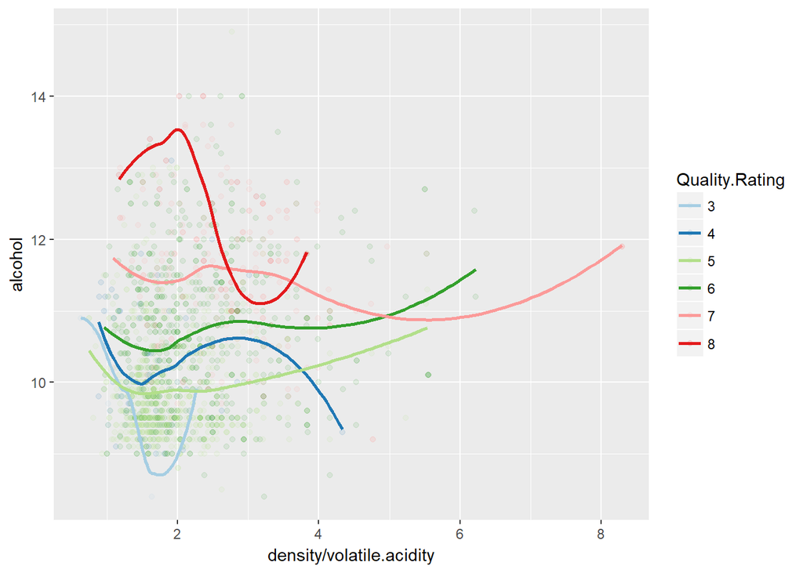

> Plotting the last two together, with density/valatile acidity creates separation between the higher and lower weighted wines, though interestingly the 5 rated wines are ofter between the 3 and 4 ranked wines. Is this reflection of the few number of 3 and 4 wines, throwing their average off?

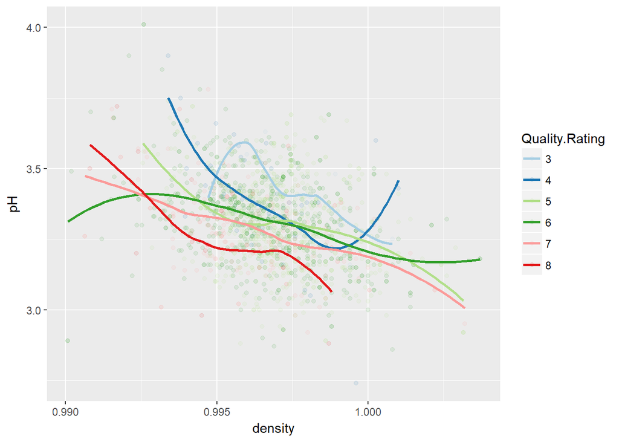

> Plotting density and PH there is a general pattern starting with higher quality ratings at lower pH and density going to lower quality at higher pH and density. There is some overlap and crossing, but with quality being a subjective rating some cross between a 4 and 5 is not surprising. There is never more than a two quality rating cross (nothing greater than 4 and 6 for example.)

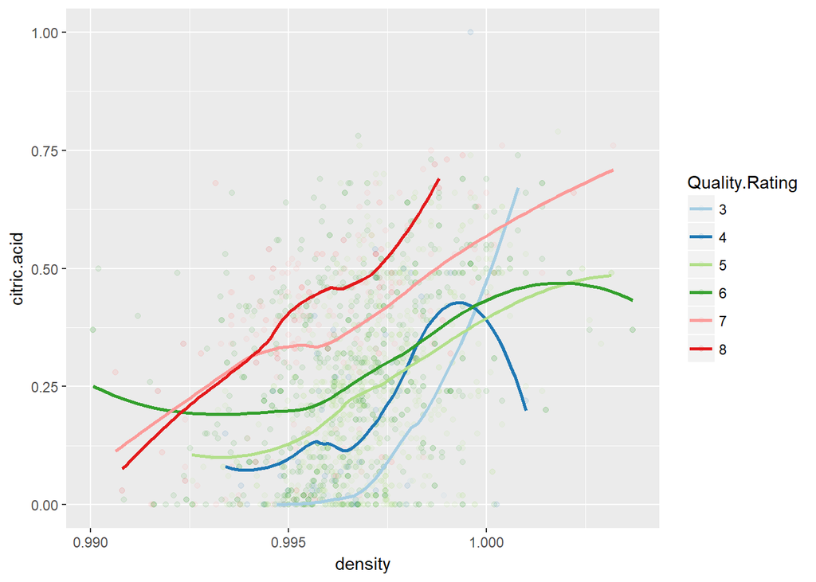

> At high citric acid and low density are the highest quality ratings, progressively moving to lower ratings at high density and low citric acid. There are so many 5 and 6 ratings that they appear over most of the map (though even there, more 6 in top left, to less in bottom right and opposite for the 5 rated), but what is telling are the ultra-low (3&4) and ultra high (7&8)

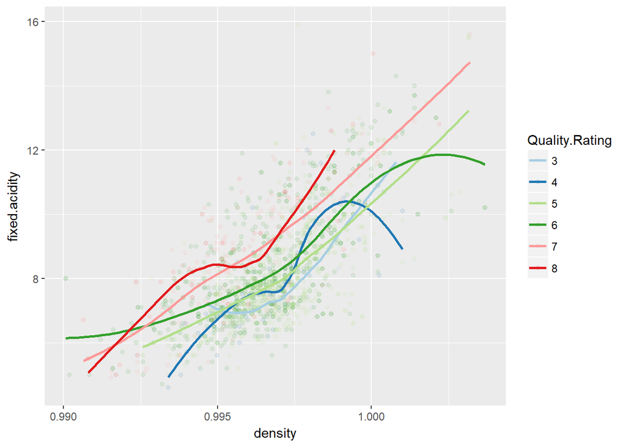

> Similar to citric acid, the higher quality rated wines are high fixed acidity, low density progressively moving to lower quality rated wines at low fixed acidity and higher density

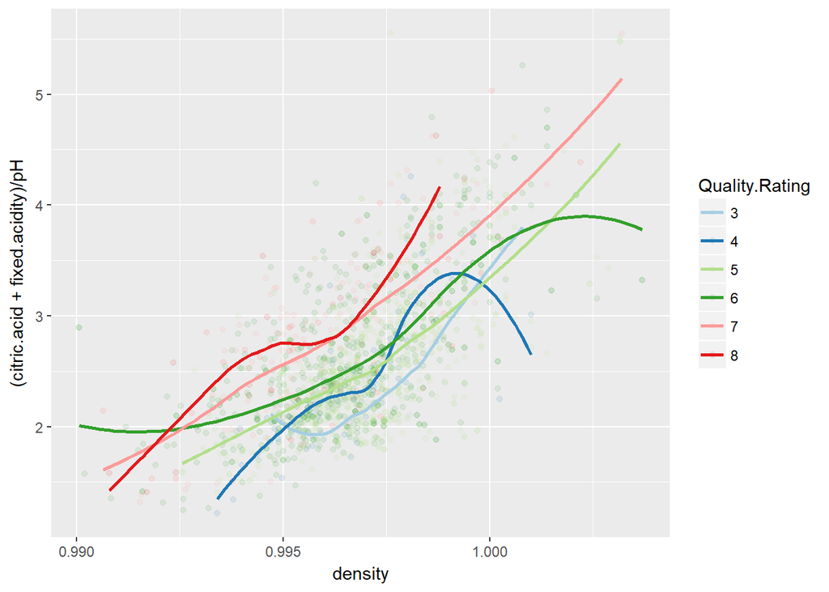

> Taking that higher citric acid, high fixed acidity, and low PH all are common for higher weighted wines, adding fixed acidity and citric acid and dividing by pH has minimumal impact on plot shape from citric acid and fixed acidity plots.

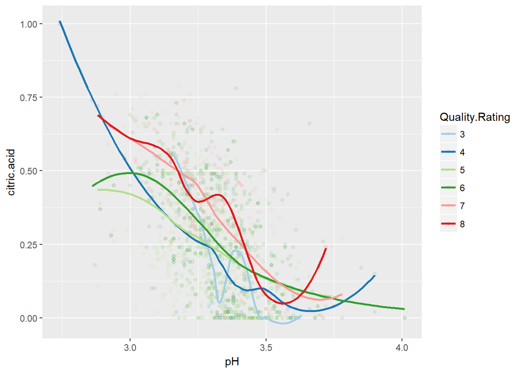

> The plot of citric acid and pH averages has a lot of cross over, with 3 rating cring over all other ratings around 3.25. This pairing is less telling.

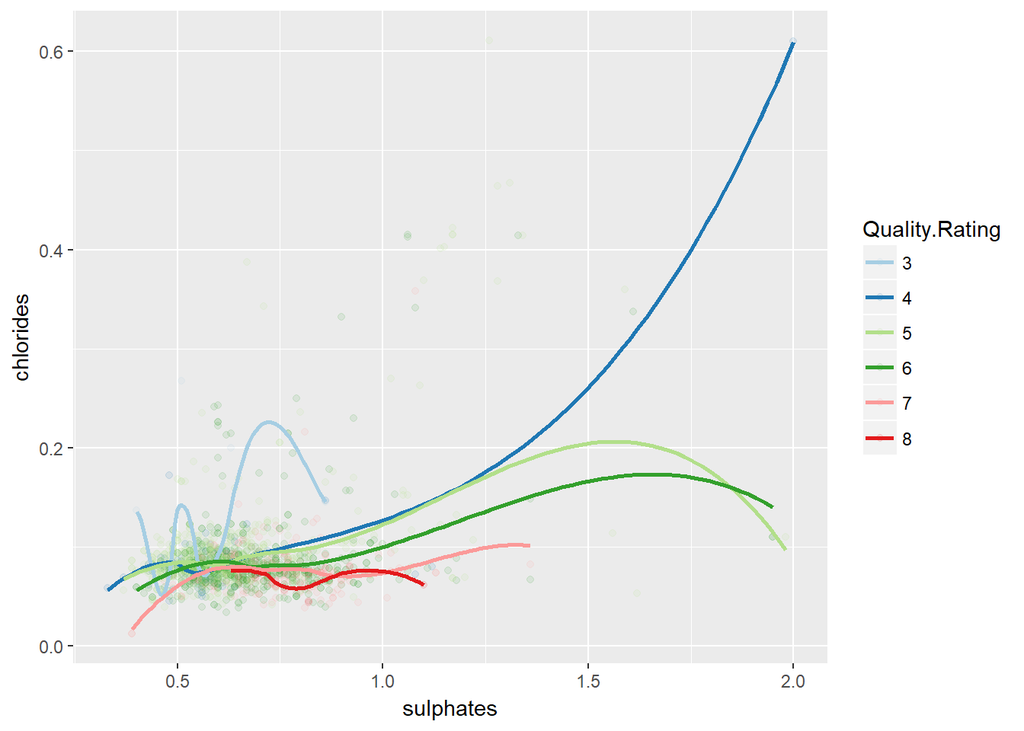

> Lower rated wines generally have higher chlorides and lower sulphates. The higher the ratings go the more average chlorides go down and sulphates go up.

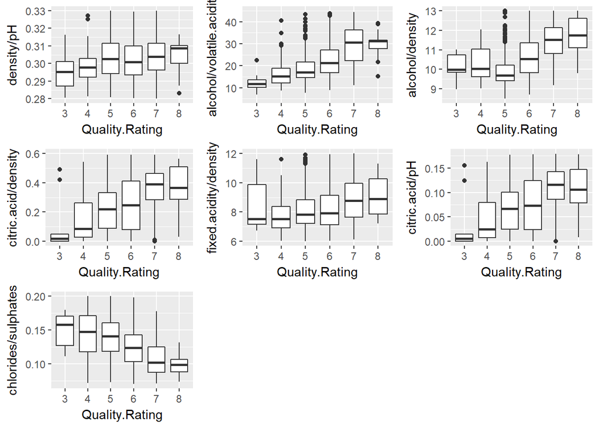

> Taking each of the lessons from the line charts about, converting them to a rate variable and plotting against the quality ratings show a trend of the averages of each.

```
##
## Calls:
## m1: lm(formula = I(quality) ~ I(alcohol), data = df)
## m2: lm(formula = I(quality) ~ I(alcohol) + density, data = df)
## m3: lm(formula = I(quality) ~ I(alcohol) + density + volatile.acidity,
##     data = df)
## m4: lm(formula = I(quality) ~ I(alcohol) + density + volatile.acidity +
##     citric.acid, data = df)
## m5: lm(formula = I(quality) ~ I(alcohol) + density + volatile.acidity +
##     citric.acid + fixed.acidity, data = df)
## m6: lm(formula = I(quality) ~ I(alcohol) + density + volatile.acidity +
##     citric.acid + fixed.acidity + pH, data = df)
##
## ========================================================================================================
##                          m1            m2            m3            m4            m5            m6
## --------------------------------------------------------------------------------------------------------
##   (Intercept)           1.875***    -33.152**     -18.407       -21.552        13.448        -1.055
##                        (0.175)      (10.878)      (10.298)      (12.039)      (15.198)      (16.787)
##   I(alcohol)            0.361***      0.391***      0.333***      0.336***      0.316***      0.338***
##                        (0.017)       (0.019)       (0.018)       (0.019)       (0.020)       (0.023)
##   density                            34.822**      21.360*       24.520*      -10.845         4.893
##                                     (10.813)      (10.228)      (11.994)      (15.223)      (17.079)
##   volatile.acidity                                 -1.365***     -1.399***     -1.405***     -1.415***
##                                                    (0.096)       (0.117)       (0.116)       (0.116)
##   citric.acid                                                    -0.061        -0.308*       -0.367**
##                                                                  (0.121)       (0.137)       (0.140)
##   fixed.acidity                                                                 0.063***      0.036
##                                                                                (0.017)       (0.022)
##   pH                                                                                         -0.352*
##                                                                                              (0.174)
## --------------------------------------------------------------------------------------------------------
##   R-squared             0.227         0.232         0.319         0.319         0.325         0.327
##   adj. R-squared        0.226         0.231         0.318         0.317         0.323         0.324
##   sigma                 0.710         0.708         0.667         0.667         0.665         0.664
##   F                   468.267       240.693       248.893       186.646       153.348       128.722
##   p                     0.000         0.000         0.000         0.000         0.000         0.000
##   Log-likelihood    -1721.057     -1715.878     -1619.631     -1619.503     -1612.485     -1610.428
##   Deviance            805.870       800.668       709.855       709.742       703.539       701.731
##   AIC                3448.114      3439.757      3249.261      3251.006      3238.969      3236.856
##   BIC                3464.245      3461.265      3276.147      3283.269      3276.609      3279.873
##   N                  1599          1599          1599          1599          1599          1599
## ========================================================================================================
```

> The simple dirty predictive model is not getting to a high r^2. It doesn’t help that the highest influencing variable (alcohol) only accounts for 22 percent of the variance in quality rating. The model tops out at a 0.327 r^2

# Multivariate Analysis

### OPTIONAL: Did you create any models with your dataset? Discuss the strengths and limitations of your model.

> Took a shot at a predictive model, but as expected it is not getting to a high r^2. This is partially due to the highest influencing variable (alcohol) only accounting for 22 percent of the variance in quality rating. With only six ratings for quality, all whole numbers with no minor scale to separate the high variance in a low vs a high 5 or 6 this model cannot become perfect. ——

# Final Plots and Summary

### Plot One

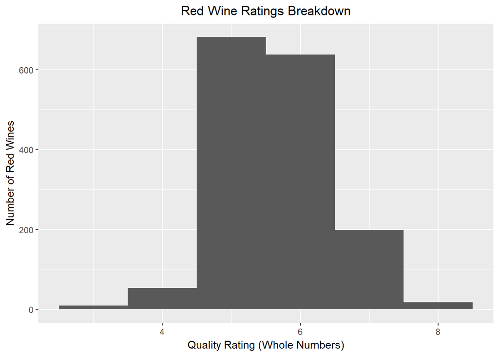

### Description One

> There is a normal distribution of the ratings of the red wines, though there is a surprising high amount of wines at the 5 and 6 rating (over 82%).

### Plot Two

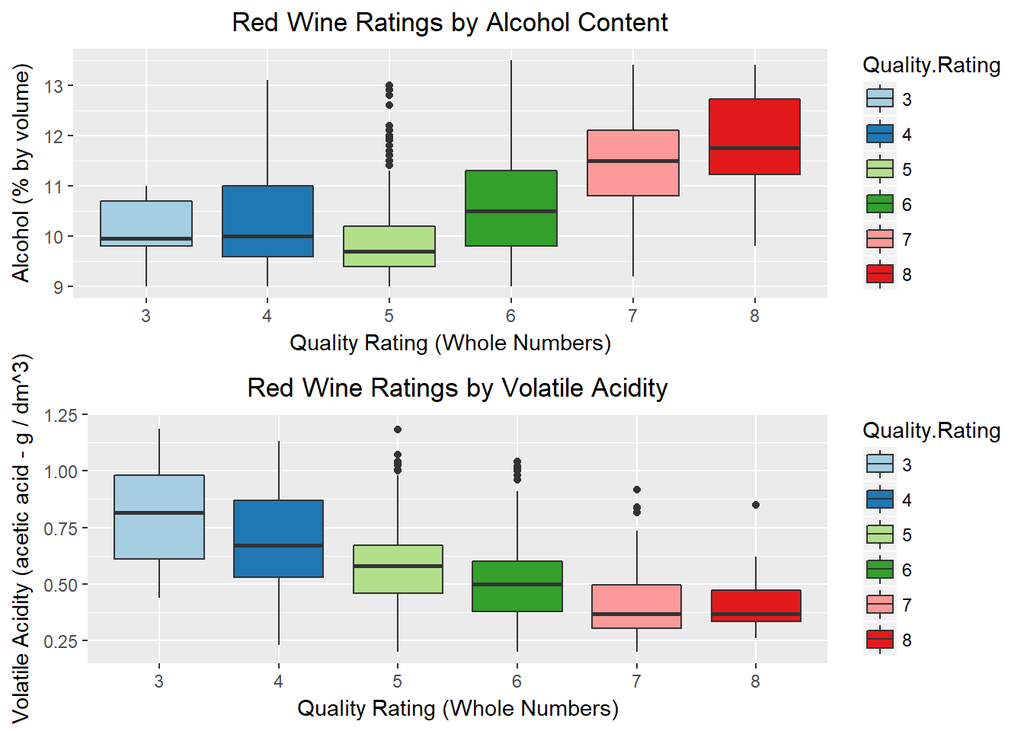

### Description Two

> Alcohol content and volatile acidity both have a pattern separating the low to high quality of red wines. Using R^2 they also have the greatest impact on the quality rating at 22 percent and 15 percent respectively.

### Plot Three

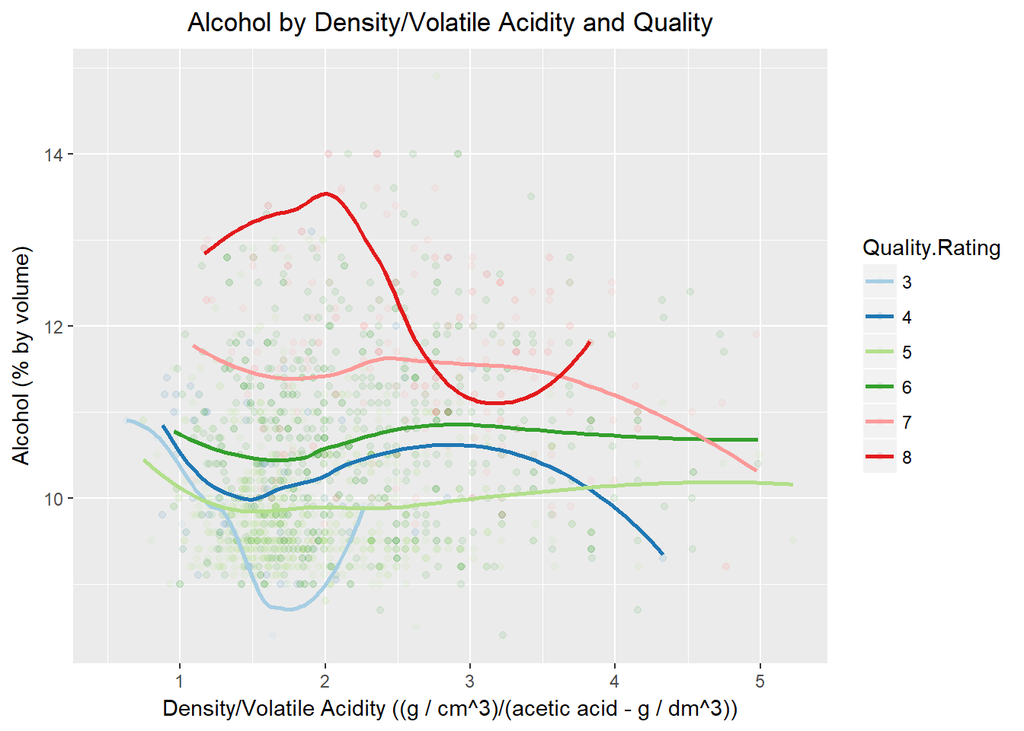

# Reflection

> The red wines data set contains information on 1599 wines with twelve variables. Quality was the one sugestive variable, so when I began by exploring each of the individual variables I did also loow at how the variables divided betweent he low and high quality ratings. Throughout the exploration I primarily focused on how the variables told the story of what was rated a higher quality wine.

> While alcohol and volatile acidity had the most influence on quality rating according to r^2 measures, this in total was less and 40% of the variation.  
> Other variable that helped to tell the story of what gets rated high quality was pH, density, citric acid, sulphates, and chlorides. Using these a model was built but could acount for only 32% of variance in the dataset.

> Some limitations which led to low performance of the model was the limits of the quality ratings. Only whole numbers were used which resulted in six categories. this led to a lot or variation in the other eleven variables for the wines in each especially for the five and six rated whens which accounted for more than 82% of wines in the dataset. It would be interesting to further explore these variables on a larger more evenly distributed between quality rating dataset.